# Reporte Villaclub - Comparativo del período 01/01/2015 al 18/08/2015 vs 01/01/2016 al 18/08/2016

## Resultados de campañas de Adwords

## Impresiones - 01/01/15 al 17/08/15 vs 01/01/16 al 17/08/16

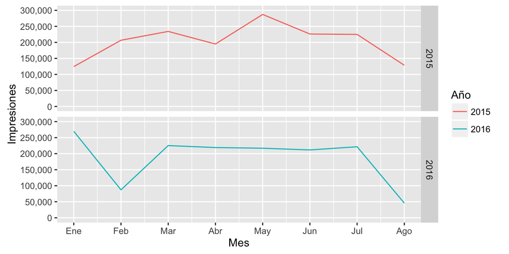

## Clicks - 01/01/15 al 17/08/15 vs 01/01/16 al 17/08/16

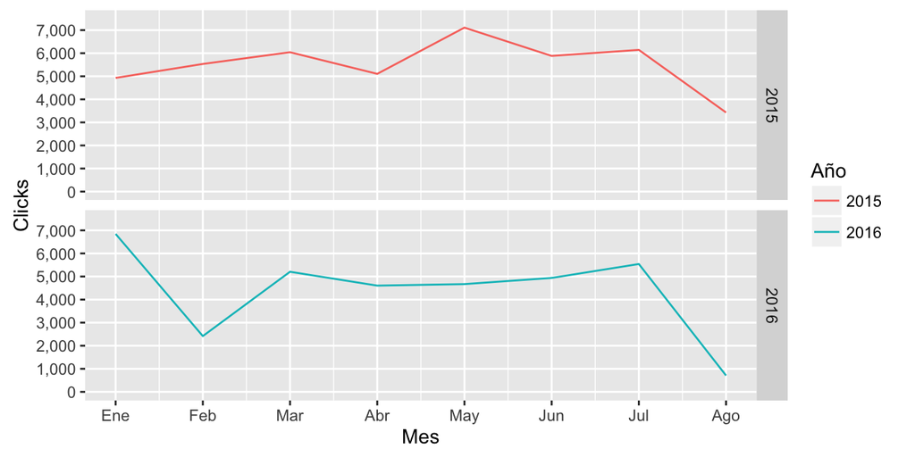

## Costo - 01/01/15 al 17/08/15 vs 01/01/16 al 17/08/16

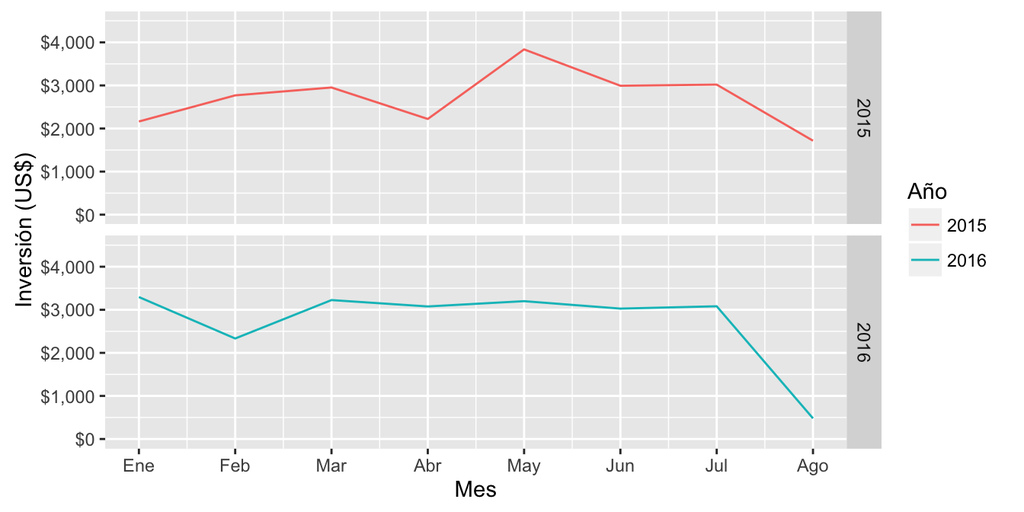

## CTR - 01/01/15 al 17/08/15 vs 01/01/16 al 17/08/16

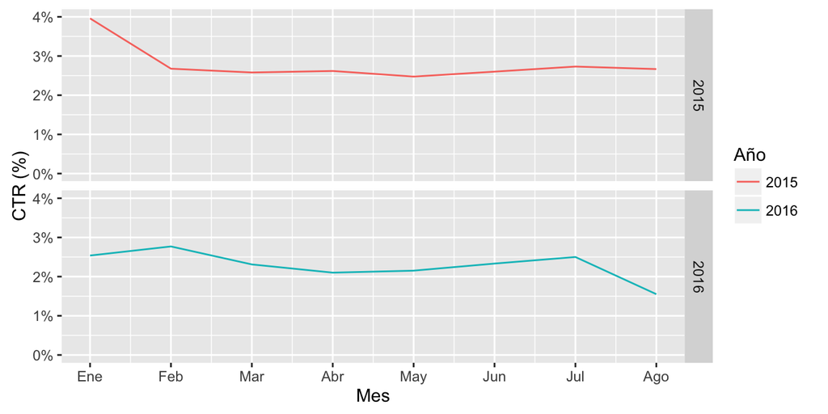

## CTO (Conversion to Opportunity) - 01/01/15 al 17/08/15 vs 01/01/16 al 17/08/16

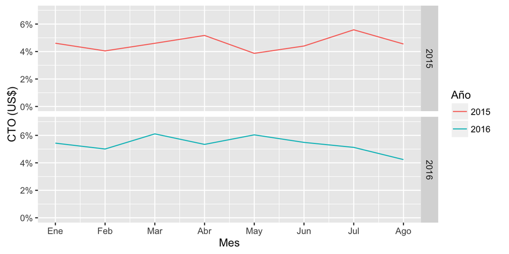

## Conversiones - 01/01/15 al 17/08/15 vs 01/01/16 al 17/08/16

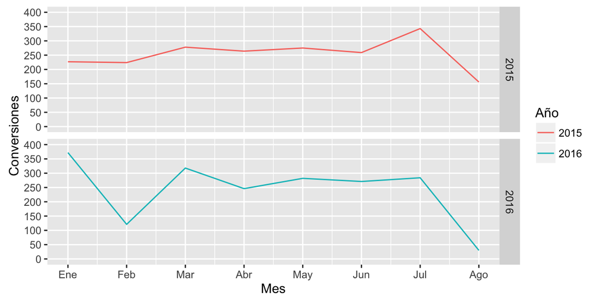

## CPC (Costo por Click) - 01/01/15 al 17/08/15 vs 01/01/16 al 17/08/16

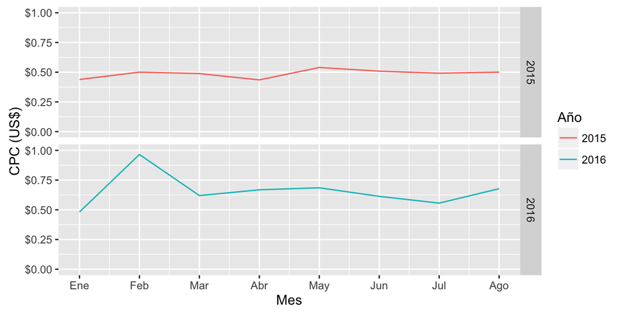

## CPM (Costo por Mil Impresiones) - 01/01/15 al 17/08/15 vs 01/01/16 al 17/08/16

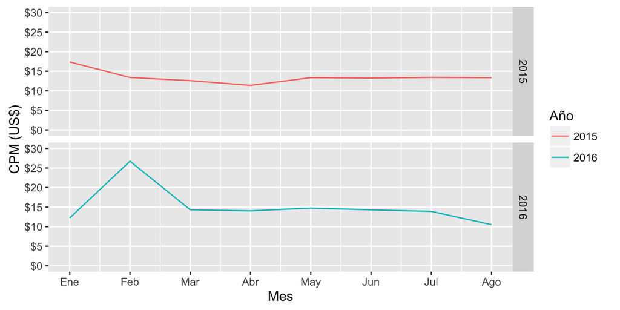

## CPO (Cost per Opportunity) - 01/01/15 al 17/08/15 vs 01/01/16 al 17/08/16

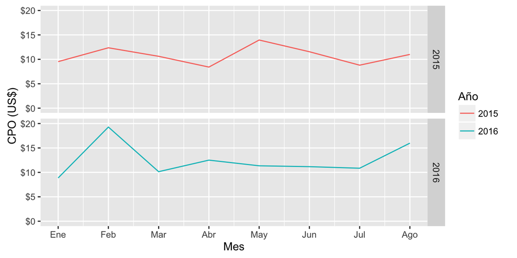

## Tabla comparativa

| Villaclub - Tabla comparativa de KPIs (2015/2016) | Villaclub - Tabla comparativa de KPIs (2015/2016) Impresiones 2015 | Villaclub - Tabla comparativa de KPIs (2015/2016) Impresiones 2016 | Villaclub - Tabla comparativa de KPIs (2015/2016) | Villaclub - Tabla comparativa de KPIs (2015/2016) Clicks 2015 | Villaclub - Tabla comparativa de KPIs (2015/2016) Clicks 2016 | Villaclub - Tabla comparativa de KPIs (2015/2016) | Villaclub - Tabla comparativa de KPIs (2015/2016) Conversiones 2015 | Villaclub - Tabla comparativa de KPIs (2015/2016) Conversiones 2016 | Villaclub - Tabla comparativa de KPIs (2015/2016) | Villaclub - Tabla comparativa de KPIs (2015/2016) Inversión (USD) 2015 | Villaclub - Tabla comparativa de KPIs (2015/2016) Inversión (USD) 2016 | Villaclub - Tabla comparativa de KPIs (2015/2016) | Villaclub - Tabla comparativa de KPIs (2015/2016) CPC (USD) 2015 | Villaclub - Tabla comparativa de KPIs (2015/2016) CPC (USD) 2016 | Villaclub - Tabla comparativa de KPIs (2015/2016) | Villaclub - Tabla comparativa de KPIs (2015/2016) CPM (USD) 2015 | Villaclub - Tabla comparativa de KPIs (2015/2016) CPM (USD) 2016 | Villaclub - Tabla comparativa de KPIs (2015/2016) | Villaclub - Tabla comparativa de KPIs (2015/2016) CPO (USD) 2015 | Villaclub - Tabla comparativa de KPIs (2015/2016) CPO (USD) 2016 | Villaclub - Tabla comparativa de KPIs (2015/2016) | Villaclub - Tabla comparativa de KPIs (2015/2016) CTO (%) 2015 | Villaclub - Tabla comparativa de KPIs (2015/2016) CTO (%) 2016 | Villaclub - Tabla comparativa de KPIs (2015/2016) | Villaclub - Tabla comparativa de KPIs (2015/2016) CTR (%) 2015 | Villaclub - Tabla comparativa de KPIs (2015/2016) CTR (%) 2016 |
| --- | --- | --- | --- | --- | --- | --- | --- | --- | --- | --- | --- | --- | --- | --- | --- | --- | --- | --- | --- | --- | --- | --- | --- | --- | --- | --- |
| Enero | 124,430 | 269,723 |  | 4,928 | 6,845 |  | 227 | 372 |  | $2,162.90 | $3,296.07 |  | $0.44 | $0.48 |  | $17.38 | $12.22 |  | $9.53 | $8.86 |  | 4.61% | 5.43% |  | 3.96% | 2.54% |
| Febrero | 206,700 | 87,263 |  | 5,533 | 2,417 |  | 224 | 121 |  | $2,769.60 | $2,333.30 |  | $0.50 | $0.97 |  | $13.40 | $26.74 |  | $12.36 | $19.28 |  | 4.05% | 5.01% |  | 2.68% | 2.77% |
| Marzo | 234,204 | 225,270 |  | 6,042 | 5,206 |  | 278 | 318 |  | $2,952.08 | $3,225.67 |  | $0.49 | $0.62 |  | $12.60 | $14.32 |  | $10.62 | $10.14 |  | 4.60% | 6.11% |  | 2.58% | 2.31% |
| Abril | 194,947 | 219,157 |  | 5,104 | 4,605 |  | 264 | 246 |  | $2,221.51 | $3,077.27 |  | $0.44 | $0.67 |  | $11.40 | $14.04 |  | $8.41 | $12.51 |  | 5.17% | 5.34% |  | 2.62% | 2.10% |
| Mayo | 287,183 | 217,043 |  | 7,109 | 4,671 |  | 275 | 282 |  | $3,837.30 | $3,200.21 |  | $0.54 | $0.69 |  | $13.36 | $14.74 |  | $13.95 | $11.35 |  | 3.87% | 6.04% |  | 2.48% | 2.15% |
| Junio | 226,110 | 211,686 |  | 5,882 | 4,938 |  | 259 | 271 |  | $2,992.57 | $3,027.42 |  | $0.51 | $0.61 |  | $13.24 | $14.30 |  | $11.55 | $11.17 |  | 4.40% | 5.49% |  | 2.60% | 2.33% |
| Julio | 224,916 | 221,619 |  | 6,143 | 5,541 |  | 343 | 284 |  | $3,019.48 | $3,081.67 |  | $0.49 | $0.56 |  | $13.42 | $13.91 |  | $8.80 | $10.85 |  | 5.58% | 5.13% |  | 2.73% | 2.50% |
| Agosto | 128,586 | 45,620 |  | 3,429 | 708 |  | 156 | 30 |  | $1,716.80 | $479.67 |  | $0.50 | $0.68 |  | $13.35 | $10.51 |  | $11.01 | $15.99 |  | 4.55% | 4.24% |  | 2.67% | 1.55% |